# Activity Recognition Project | Practical Machine Learning

Andrew Martin

Read in the data:

```r
pml_train <- read.csv(
  'https://d396qusza40orc.cloudfront.net/predmachlearn/pml-training.csv',
  stringsAsFactors = FALSE
)

pml_validation <- read.csv(
  'https://d396qusza40orc.cloudfront.net/predmachlearn/pml-testing.csv',
  stringsAsFactors = FALSE
)
```

**Data cleaning:**

Eliminate `#DIV/0!` errors and code empty strings as NA

```r
for (i in 1:ncol(pml_train)) {
  pml_train[, i] <- ifelse(pml_train[, i] == '#DIV/0!', NA, pml_train[, i])
  pml_train[, i] <- ifelse(pml_train[, i] == '', NA, pml_train[, i])
}

pml_train$classe <- as.factor(pml_train$classe)
```

## Goal, and Exploratory Analysis

The data comes from a Brazilian lab focusing on Human Activity Recognition. Here’s how they describe the data:

> Six young health participants were asked to perform one set of 10 repetitions of the Unilateral Dumbbell Biceps Curl in five different fashions: exactly according to the specification (Class A), throwing the elbows to the front (Class B), lifting the dumbbell only halfway (Class C), lowering the dumbbell only halfway (Class D) and throwing the hips to the front (Class E).

The goal is to use the training data to fit a model that correctly classifies the weight lifting exercise into classes `A, B, C, D, E`, based on a variety of sensor measures.

We have fairly reasonable coverage of the five classes

```r
table(pml_train$classe)
```

```
##
##    A    B    C    D    E
## 5580 3797 3422 3216 3607
```

so we don’t need to worry too much about skewed classes - we’re close enough to equal representation of each class that the classifier isn’t going to, say, minimize error by always predicting class A.

The first challenge is just the sheer number of variables present in the data set. I looked around for a data documentation, but couldn’t find much on the HAR website that described the data set. In particular, I wanted to know more about how independent trials were coded in the data set. There is a `num_window` field that seems to increment up numerically, and then reset. But because our test dataset seems to have random slices with no sequential patterns of `num_window`, I am going to proceed as if each of these rows represented an independent dumbell lift, even though that over-simplifies the complexity of the data captured here.

To gain some basic intuition on the data, I first looked at the raw correlation of each variable to `classe`.

```r
cors <- sapply(
  X = pml_train,
  function(x) {
    tryCatch(
      cor(as.numeric(x), as.numeric(pml_train$classe), use = "complete.obs"),
      error = function(e) return(NA)
    )
  }
)

sort(cors, decreasing = TRUE)[1:10]
```

```
##               classe                    X amplitude_pitch_belt
##            1.0000000            0.9741802            0.5400009
##     stddev_roll_belt var_total_accel_belt    stddev_pitch_belt
##            0.5186525            0.4424690            0.4342073
##     min_roll_forearm        var_roll_belt       var_pitch_belt
##            0.4063622            0.3905484            0.3741772
##        pitch_forearm
##            0.3438258
```

```r
sort(cors)[1:10]
```

```
##    magnet_belt_y      min_yaw_arm     magnet_arm_y     min_roll_arm
##       -0.2903491       -0.2661351       -0.2566702       -0.2099891
##  accel_forearm_x magnet_forearm_x    avg_pitch_arm    magnet_belt_z
##       -0.1886854       -0.1821334       -0.1820083       -0.1800306
##        pitch_arm kurtosis_yaw_arm
##       -0.1776849       -0.1747052
```

The correlation with `X` (the index of the dataframe) is almost certainly spurious - it simply indicates that the training spreadsheet was sorted by `classe` before distribution. We’ll throw that out. We’ll also throw out timestamp, as that cannot be important to our final model. Other important observations seem to focus on the variance in the belt, and the y and yaw variables for the magnet belt and the arm.

```r
pml_train <- pml_train[, !names(pml_train) %in% c('X', 'cvtd_timestamp')]
```

## How I built the model & choices made

I investigated to see which columns had significant missing data:

```r
pml_missing <- sapply(
  X = pml_train,
  function(x) sum(is.na(x))
)

sort(pml_missing, decreasing = TRUE)[1:10]
```

```
##      kurtosis_yaw_belt      skewness_yaw_belt  kurtosis_yaw_dumbbell
##                  19622                  19622                  19622
##  skewness_yaw_dumbbell   kurtosis_yaw_forearm   skewness_yaw_forearm
##                  19622                  19622                  19622
## kurtosis_picth_forearm skewness_pitch_forearm  kurtosis_roll_forearm
##                  19301                  19301                  19300
##        max_yaw_forearm
##                  19300
```

```r
mask <- (pml_missing / nrow(pml_train) < .5) %>% unname()
to_keep <- names(pml_train)[mask]
pml_subset <- pml_train[, to_keep]
```

because many of the methods below (eg, random forest) cannot handle variables that consist entirely of missing data, I am drop variables that has significant missingness from our training set.

I chose to do some additional pre-processing and excluded variables that had a correlation with classe +/- .1 from zero, to reduce the number of dimensions the caret models needed to consider. If time allowed, I also would have investigated primary component analysis approaches that helped to surface the most important features fo the dataset.

```r
to_keep <- cors[(abs(cors) > .1) | is.na(cors)] %>% names()
mask <- names(pml_subset) %in% to_keep
pml_subset <- pml_subset[, mask]
```

The course project presents two files - one ‘training’ set, and one ‘test’ set. Because we don’t have the `classe` values for the ‘test’ set, that file can more properly be thought of as validation. We’ll split our training data into a train and test set.

```r
trainIndex <- createDataPartition(
  y = pml_subset$classe,
  p = .7,
  list = FALSE,
  times = 1
)

pml_testset  <- pml_subset[-trainIndex, ]
pml_train <- pml_subset[trainIndex, ]
```

I experimented with a few different model specifications, but after examining fit statistics / accuracy, I found that random forests and boosted trees were both strong, achieving accuracy above 85% on my holdout data.

```r
model_control <- trainControl(
  method = 'cv', number = 3, summaryFunction = defaultSummary
)
```

**Random Forest**

```r
rf_model <- train(
  classe ~ .,
  data = pml_train,
  method = "rf",
  allowParallel = TRUE,
  trControl = model_control
)
```

```r
summary(rf_model)
```

```
##                 Length Class      Mode
## call                5  -none-     call
## type                1  -none-     character
## predicted       13737  factor     numeric
## err.rate         3000  -none-     numeric
## confusion          30  -none-     numeric
## votes           68685  matrix     numeric
## oob.times       13737  -none-     numeric
## classes             5  -none-     character
## importance         21  -none-     numeric
## importanceSD        0  -none-     NULL
## localImportance     0  -none-     NULL
## proximity           0  -none-     NULL
## ntree               1  -none-     numeric
## mtry                1  -none-     numeric
## forest             14  -none-     list
## y               13737  factor     numeric
## test                0  -none-     NULL
## inbag               0  -none-     NULL
## xNames             21  -none-     character
## problemType         1  -none-     character
## tuneValue           1  data.frame list
## obsLevels           5  -none-     character
```

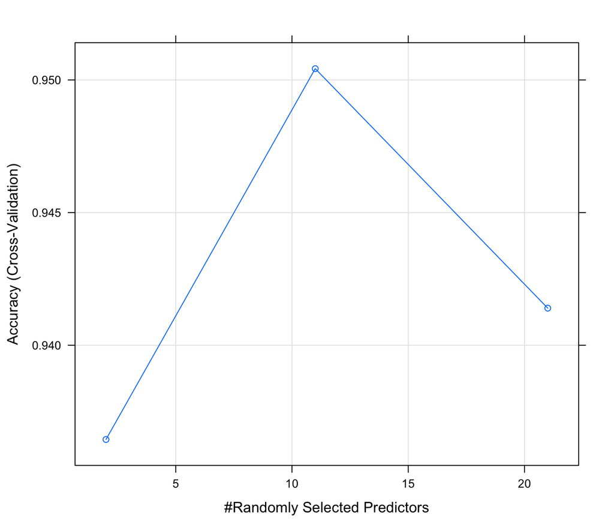

```r
plot(rf_model)
```

```r
varImp(rf_model)
```

```
## rf variable importance
##
##   only 20 most important variables shown (out of 21)
##
##                     Overall
## magnet_dumbbell_z   100.000
## pitch_forearm        90.847
## accel_dumbbell_x     65.757
## magnet_belt_y        63.541
## magnet_belt_z        61.590
## pitch_arm            38.439
## accel_forearm_x      36.885
## magnet_forearm_y     35.613
## magnet_arm_z         33.655
## magnet_forearm_x     32.074
## magnet_arm_y         31.867
## accel_arm_x          27.939
## magnet_arm_x         27.753
## total_accel_forearm  23.097
## total_accel_arm      17.137
## user_nameeurico      14.397
## user_namecharles      6.735
## user_namepedro        3.094
## user_namecarlitos     3.017
## user_namejeremy       1.932
```

**Boosted Predictor**

```r
bp_model <- train(
  classe ~ .,
  data = pml_train,
  method = "gbm",
  trControl = model_control
)
```

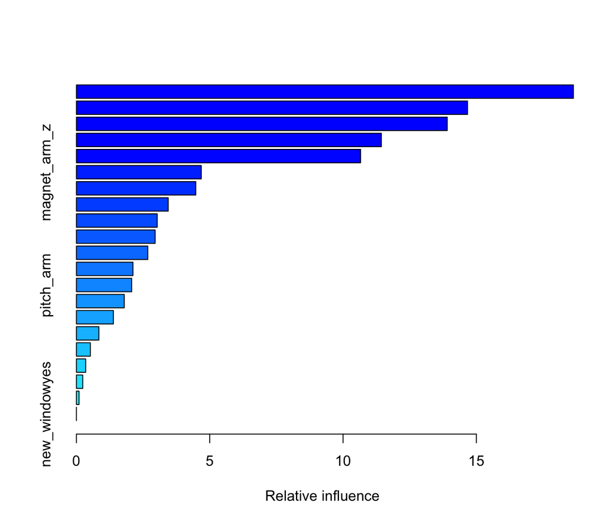

```
##                                     var     rel.inf
## pitch_forearm             pitch_forearm 18.64024773
## magnet_belt_y             magnet_belt_y 14.66970844
## magnet_dumbbell_z     magnet_dumbbell_z 13.90923929
## accel_dumbbell_x       accel_dumbbell_x 11.43775030
## magnet_belt_z             magnet_belt_z 10.65866381
## magnet_arm_z               magnet_arm_z  4.68383201
## user_nameeurico         user_nameeurico  4.47689835
## accel_forearm_x         accel_forearm_x  3.44236039
## magnet_forearm_x       magnet_forearm_x  3.03140356
## magnet_arm_y               magnet_arm_y  2.95235719
## magnet_forearm_y       magnet_forearm_y  2.67659473
## user_namecharles       user_namecharles  2.12132890
## pitch_arm                     pitch_arm  2.07259565
## magnet_arm_x               magnet_arm_x  1.79336949
## accel_arm_x                 accel_arm_x  1.38620873
## total_accel_forearm total_accel_forearm  0.84154263
## user_namejeremy         user_namejeremy  0.52268469
## user_namecarlitos     user_namecarlitos  0.34691862
## total_accel_arm         total_accel_arm  0.23770283
## user_namepedro           user_namepedro  0.09859265
## new_windowyes             new_windowyes  0.00000000
```

```r
summary(bp_model)
```

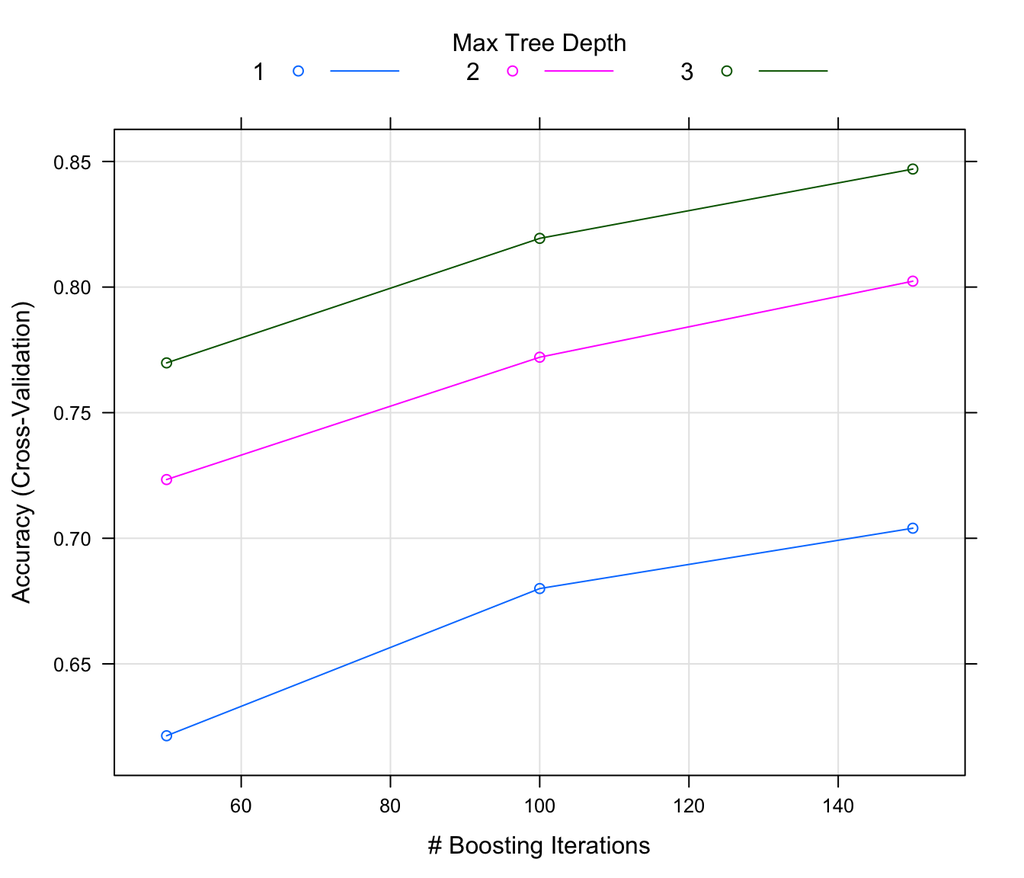

```r
plot(bp_model)
```

```r
varImp(bp_model)
```

```
## gbm variable importance
##
##   only 20 most important variables shown (out of 21)
##
##                      Overall
## pitch_forearm       100.0000
## magnet_belt_y        78.6991
## magnet_dumbbell_z    74.6194
## accel_dumbbell_x     61.3605
## magnet_belt_z        57.1809
## magnet_arm_z         25.1275
## user_nameeurico      24.0174
## accel_forearm_x      18.4674
## magnet_forearm_x     16.2627
## magnet_arm_y         15.8386
## magnet_forearm_y     14.3592
## user_namecharles     11.3804
## pitch_arm            11.1189
## magnet_arm_x          9.6210
## accel_arm_x           7.4366
## total_accel_forearm   4.5147
## user_namejeremy       2.8041
## user_namecarlitos     1.8611
## total_accel_arm       1.2752
## user_namepedro        0.5289
```

## Cross-validation strategy

When fitting the random forest and boosted tree models, I’m using a 3-fold cross-validation with my training data. Additionally, I’m holding out 30% of the training data as a test set, and using that to validate the model.

## Accuracy and error

First, we make a prediction on the test set for each model

```r
rf_test <- predict(rf_model, newdata = pml_testset)
bp_test <- predict(bp_model, newdata = pml_testset)
```

Then, we calculate a confusion matrix for each model, which also reports accuracy and recall measures.

```r
confusionMatrix(rf_test, pml_testset$classe)
```

```
## Confusion Matrix and Statistics
##
##           Reference
## Prediction    A    B    C    D    E
##          A 1648   38    1    5    1
##          B   13 1085   17    6    6
##          C    4    9  991   52   10
##          D    7    5   13  897   13
##          E    2    2    4    4 1052
##
## Overall Statistics
##
##                Accuracy : 0.964
##                  95% CI : (0.9589, 0.9686)
##     No Information Rate : 0.2845
##     P-Value [Acc > NIR] : < 2.2e-16
##
##                   Kappa : 0.9544
##  Mcnemar's Test P-Value : 2.658e-07
##
## Statistics by Class:
##
##                      Class: A Class: B Class: C Class: D Class: E
## Sensitivity            0.9845   0.9526   0.9659   0.9305   0.9723
## Specificity            0.9893   0.9912   0.9846   0.9923   0.9975
## Pos Pred Value         0.9734   0.9627   0.9296   0.9594   0.9887
## Neg Pred Value         0.9938   0.9887   0.9927   0.9865   0.9938
## Prevalence             0.2845   0.1935   0.1743   0.1638   0.1839
## Detection Rate         0.2800   0.1844   0.1684   0.1524   0.1788
## Detection Prevalence   0.2877   0.1915   0.1811   0.1589   0.1808
## Balanced Accuracy      0.9869   0.9719   0.9752   0.9614   0.9849
```

```r
confusionMatrix(bp_test, pml_testset$classe)
```

```
## Confusion Matrix and Statistics
##
##           Reference
## Prediction    A    B    C    D    E
##          A 1544  109   30   25   22
##          B   61  902   68   22   36
##          C   25   85  873   96   66
##          D   40   33   39  804   50
##          E    4   10   16   17  908
##
## Overall Statistics
##
##                Accuracy : 0.8549
##                  95% CI : (0.8456, 0.8638)
##     No Information Rate : 0.2845
##     P-Value [Acc > NIR] : < 2.2e-16
##
##                   Kappa : 0.8163
##  Mcnemar's Test P-Value : < 2.2e-16
##
## Statistics by Class:
##
##                      Class: A Class: B Class: C Class: D Class: E
## Sensitivity            0.9223   0.7919   0.8509   0.8340   0.8392
## Specificity            0.9558   0.9606   0.9440   0.9671   0.9902
## Pos Pred Value         0.8925   0.8283   0.7624   0.8323   0.9508
## Neg Pred Value         0.9687   0.9506   0.9677   0.9675   0.9647
## Prevalence             0.2845   0.1935   0.1743   0.1638   0.1839
## Detection Rate         0.2624   0.1533   0.1483   0.1366   0.1543
## Detection Prevalence   0.2940   0.1850   0.1946   0.1641   0.1623
## Balanced Accuracy      0.9391   0.8763   0.8974   0.9006   0.9147
```

## Score validation set

This is the code that I used to spit out the 20 predicted classifications for the final quiz.

```r
final <- predict(rf_model, newdata = pml_validation)

data.frame(
  number = c(1:20),
  prediction = final
)
```

```
##    number prediction
## 1       1          B
## 2       2          A
## 3       3          B
## 4       4          A
## 5       5          A
## 6       6          E
## 7       7          D
## 8       8          B
## 9       9          A
## 10     10          A
## 11     11          B
## 12     12          C
## 13     13          B
## 14     14          A
## 15     15          E
## 16     16          E
## 17     17          A
## 18     18          B
## 19     19          B
## 20     20          B
```